# Pain Differences Between Sexes

### Zachary Traylor’s Master’s Thesis

## The Dataset

[*Distinct patterns of brain activity mediate perceptual and motor and autonomic responses to noxious stimuli*](https://www.nature.com/articles/s41467-018-06875-x) by Tiemann et al. (2018) collected physiological and behavioral recordings from subjects exposed to noxious stimulus. Participants (N=51, 26 male), all between the age of 20-37 years, were recruited from local universities in Germany. Subejcts had no history of neurological and psychiatric diseases, including current or recurrent pain as well as no regular use of medication.

Subjects had painful stimulus applied to the dorsum of their left hand via cutaneous laser stimulation. A pain threshold was determined at the start of the experience, and stimulus that was rated 30, 50, and 70 (out of 100) were used for the low-, medium-, and high-intensity stimulation levels, respectively.

During the study, each subject participated in 4 conditions: Perception, EDA, Motor, and Control. In each condition, they were exposed to 20 stimulations of each level (low, med, and high) for 60 stimulations per condition. Each condition had its own behavioral task detailed below:

1. **Perception**: Subjects were instructed to verbally rate the perceived level of pain from 0-100, with 100 being the worst pain. Verbal responses were encoded.
2. **EDA**: Subjects were instructed to do nothing but focus on the stimulus. GSR data was collected on their left index and middle finger.
3. **Motor**: Subjects were instructed to press a button with their right hand as fast as possible after the painful stimulus. Reaction times (in ms) were encoded
4. **Control**: Subjects completed all of the previous 3 tasks at once. First, they would press the button as fast as possible, then verbally report their perceived pain. During this, GSR was collected.

This data was chosen for analysis due to the focus on pain-related evoked potentials (PREPs) high quality of the documentation, large sample size, and lack of investigation towards sex differences included in the original publication.

$~$

$~$

## One-Way ANOVA on Pain Threshold Data

Load the Pain Threshold data. This is the level of laser stimulation (in mJ) that the subject reported as painful. Data is grouped by male and female.

```r
threshold <- read_csv("Thresholds.csv", col_types = cols(Sex = col_factor(
                                                       levels = c("male", "female"))))
```

Visualize the distributions via their box plots. Also, analyze normality visually.

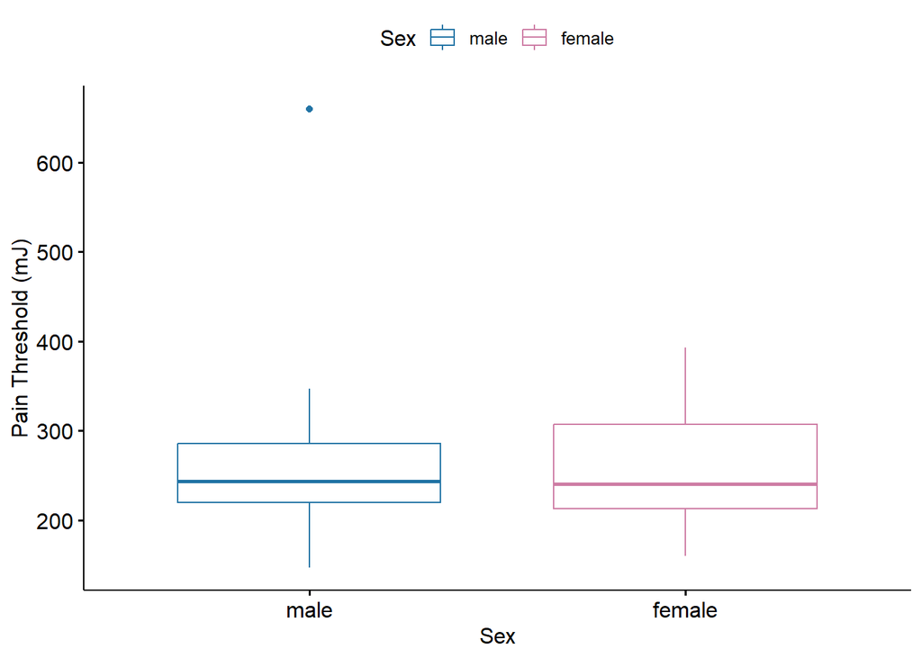

```r
ggboxplot(threshold, x = "Sex", y = "Threshold",
          color = "Sex", palette = c("#2274A5", "#CE7DA5"),
          ylab = "Pain Threshold (mJ)", xlab = "Sex")
```

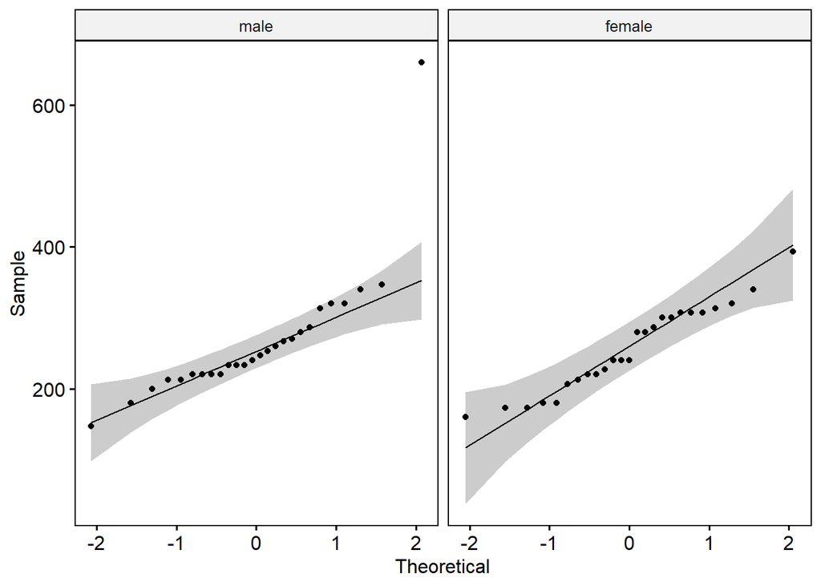

```r
ggqqplot(threshold, "Threshold", facet.by = "Sex")
```

```r
print(c("Male average: ", mean(subset(threshold, threshold$Sex=="male")$Threshold)))
```

```
## [1] "Male average: "   "266.769230769231"
```

```r
print(c("Male variance: ", sd(subset(threshold, threshold$Sex=="male")$Threshold)))
```

```
## [1] "Male variance: "  "93.9056154624664"
```

```r
print(c("Female average: ", mean(subset(threshold, threshold$Sex=="female")$Threshold)))
```

```
## [1] "Female average: " "256.28"
```

```r
print(c("Female variance: ", sd(subset(threshold, threshold$Sex=="female")$Threshold)))
```

```
## [1] "Female variance: " "61.2212653686065"
```

One outlier can be seen, subject #33. Removing them does not heavily affect the ANOVA output.

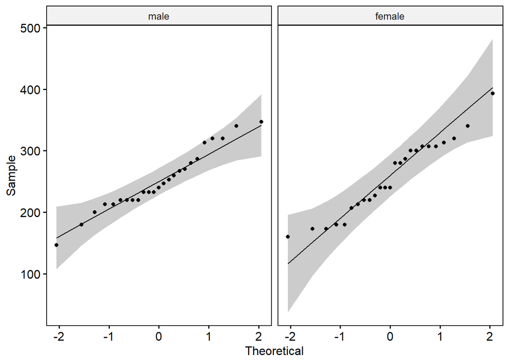

```r
threshold <- subset(threshold, threshold$Subject != 33)
ggqqplot(threshold, "Threshold", facet.by = "Sex")
```

Computing the ANOVA, we see no significant difference between men and women’s pain threshold. This lack of significance persists when an addition term is added to capture between subject variance, by the way.

```r
thresh.aov <- aov(Threshold ~ Sex, data = threshold)
summary(thresh.aov)
```

```
##             Df Sum Sq Mean Sq F value Pr(>F)
## Sex          1    343   343.2    0.11  0.741
## Residuals   48 149594  3116.5
```

Now we check that all ANOVA assumptions are met. First, independence of observations is met because each subject is either male or female, never both. Second, homogeneity of variance is tested with Levene’s test (note that a significant result indicates non-homogeneity and thus a violation of the assumption). Lastly, the Shapiro-Wilk test to gauge normality of the dataset (again, a significant result would indicate non-normality and a violation of the assumption of normality). For both of these tests, α = 0.05.

```r
leveneTest(Threshold ~ Sex, data = threshold)
```

```
## Levene's Test for Homogeneity of Variance (center = median)
##       Df F value Pr(>F)
## group  1  1.9325 0.1709
##       48
```

```r
shapiro.test(x = residuals(object = thresh.aov))
```

```
##
##  Shapiro-Wilk normality test
##
## data:  residuals(object = thresh.aov)
## W = 0.97958, p-value = 0.5342
```

$~$

$~$

## ANOVA on Verbal Pain Rating Data

Load in the Pain Rating data. This is sourced from two conditions, Perception and Control, as these were the only two conditions of the original study that collected verbal pain ratings (from 0-100, 100 being most intense pain).

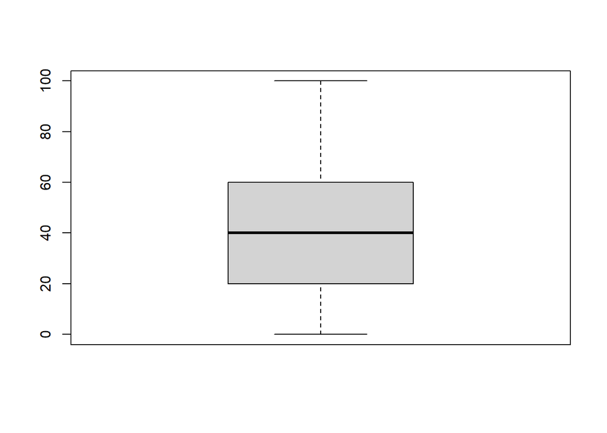

```r
R1 <- read_csv("Perception_ratings.csv", col_types = cols(Sex = col_factor(
                                                          levels = c("male", "female")),
                                                          Stim = col_factor(
                                                          levels = c("low", "med", "high"))))
R1$Condition <- "Perception"
R2 <- read_csv("Control_ratings.csv", col_types = cols(Sex = col_factor(
                                                       levels = c("male", "female")),
                                                       Stim = col_factor(
                                                       levels = c("low", "med", "high"))))
R2$Condition <- "Control"

ratings <- rbind(R1, R2)
ratings <- subset(ratings, ratings$Subject!=18)  # exclude subject 18 (DNF motor)
ratings <- ratings[!(ratings$Pain %in% boxplot(ratings$Pain)$out),]  # remove rows with outliers
```

```r
print("Sample Size")
```

```
## [1] "Sample Size"
```

```r
print(length(ratings$Pain))
```

```
## [1] 5998
```

```r
emm_options(pbkrtest.limit = 5000)
ratings <- na.omit(ratings)
ratings <- ratings[sample(nrow(ratings), 5000), ]
```

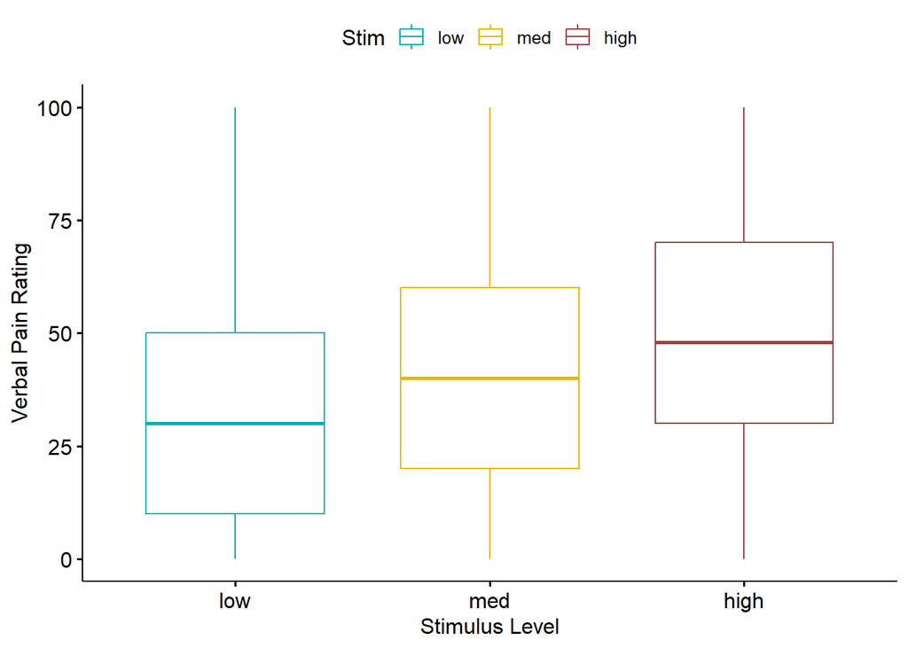

```r
ggboxplot(ratings, x = "Stim", y = "Pain",
          color = "Stim", palette = c("#00AFBB", "#E7B800", "#A03D41"),
          ylab = "Verbal Pain Rating", xlab = "Stimulus Level",
          order = c("low", "med", "high"))
```

```r
for (i in c("male", "female")) {
  print(table(ratings$Sex))
  for (j in c("low", "med", "high")){
    print(table(ratings$Stim))
    for (k in c("Perception", "Control")){
      print(table(ratings$Condition))
      m <- mean(subset(ratings, ratings$Sex==i & ratings$Stim==j & ratings$Condition==k)$Pain, na.rm = TRUE)
      s <- sd(subset(ratings, ratings$Sex==i & ratings$Stim==j & ratings$Condition==k)$Pain, na.rm = TRUE)
      print(sprintf("%s %s %s - %s (%s)", i, j, k, round(m, digits = 1), round(s, digits = 1)))
    }
  }
}
```

```
##
##   male female
##   2504   2496
##
##  low  med high
## 1645 1686 1669
##
##    Control Perception
##       2460       2540
## [1] "male low Perception - 38.2 (25.3)"
##
##    Control Perception
##       2460       2540
## [1] "male low Control - 39.1 (24.1)"
##
##  low  med high
## 1645 1686 1669
##
##    Control Perception
##       2460       2540
## [1] "male med Perception - 44 (24.6)"
##
##    Control Perception
##       2460       2540
## [1] "male med Control - 44.1 (23.5)"
##
##  low  med high
## 1645 1686 1669
##
##    Control Perception
##       2460       2540
## [1] "male high Perception - 49.4 (23.1)"
##
##    Control Perception
##       2460       2540
## [1] "male high Control - 50.8 (22.1)"
##
##   male female
##   2504   2496
##
```

[output cut: 17 more lines]

```
##
##    Control Perception
##       2460       2540
## [1] "female med Control - 39.1 (25.1)"
##
##  low  med high
## 1645 1686 1669
##
##    Control Perception
##       2460       2540
## [1] "female high Perception - 42.6 (26.5)"
##
##    Control Perception
##       2460       2540
## [1] "female high Control - 46.4 (26.8)"
```

To know if there is a statistical difference, we must model pain ratings as a factor of sex, but control for the effects of stimulus and Condition. Furthermore, we introduce a repeated-measures aspect to account for individual variances in subject pain perception.

```r
pain.model <- aov_ez(id = "Subject",
                     dv = "Pain",
                     data = ratings,
                     between = "Sex",
                     within = c("Stim", "Condition"),
                     fun_aggregate = mean)
```

```
## Contrasts set to contr.sum for the following variables: Sex
```

```r
knitr::kable(nice(pain.model))
```

| Effect | df | MSE | F | ges | p.value |
| --- | --- | --- | --- | --- | --- |
| Sex | 1, 48 | 2017.31 | 1.72 | .030 | .196 |
| Stim | 1.25, 59.79 | 52.77 | 126.82 *** | .070 | <.001 |
| Sex:Stim | 1.25, 59.79 | 52.77 | 2.39 | .001 | .121 |
| Condition | 1, 48 | 202.74 | 1.11 | .002 | .296 |
| Sex:Condition | 1, 48 | 202.74 | 0.49 | <.001 | .489 |
| Stim:Condition | 1.76, 84.48 | 18.81 | 1.17 | <.001 | .310 |
| Sex:Stim:Condition | 1.76, 84.48 | 18.81 | 0.33 | <.001 | .694 |

```r
post.hoc <- emmeans(pain.model, ~ Stim)  # significant main effect of Stimulus
print(summary(as.glht(pairs(post.hoc)), test=adjusted("bonferroni")))
```

```
##
##   Simultaneous Tests for General Linear Hypotheses
##
## Linear Hypotheses:
##                 Estimate Std. Error t value Pr(>|t|)
## low - med == 0   -6.6688     0.6021 -11.075 2.40e-14 ***
## low - high == 0 -12.9109     1.0802 -11.952 1.33e-15 ***
## med - high == 0  -6.2421     0.6654  -9.381 5.90e-12 ***
## ---
## Signif. codes:  0 '***' 0.001 '**' 0.01 '*' 0.05 '.' 0.1 ' ' 1
## (Adjusted p values reported -- bonferroni method)
```

1. Visualization is a safer way to confirm normality for such a high sample size

   ```r
   R = residuals(pain.model)
   ```

   ```
   ## Data was changed during ANOVA calculation. Thus, residuals cannot be added to original data.
   ## residuals(..., append = TRUE) will return data and residuals.
   ```

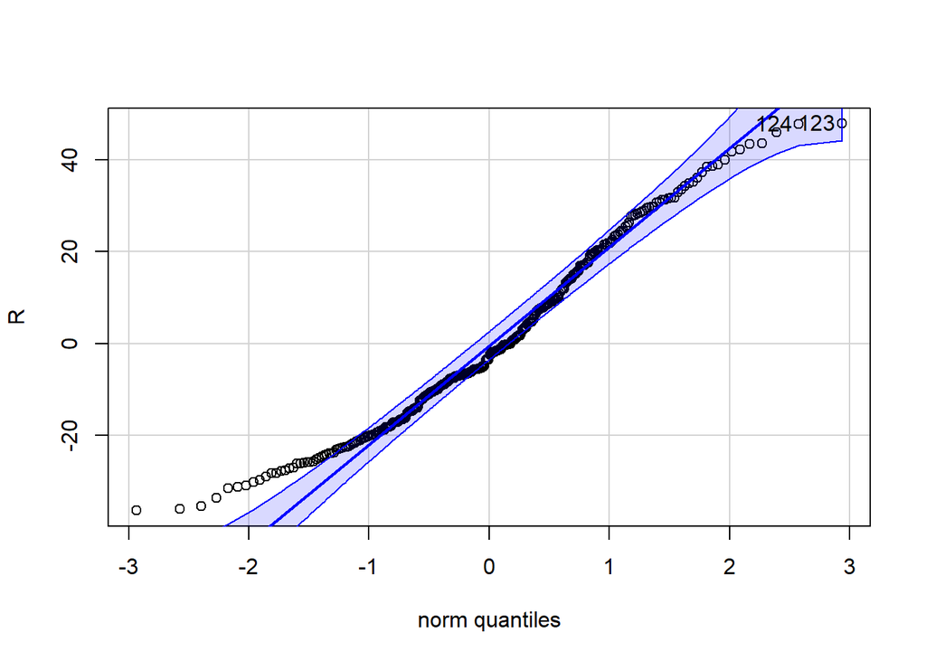

   ```
   ## [1] 123 124
   ```

   ```r
   qqPlot(R)
   ```

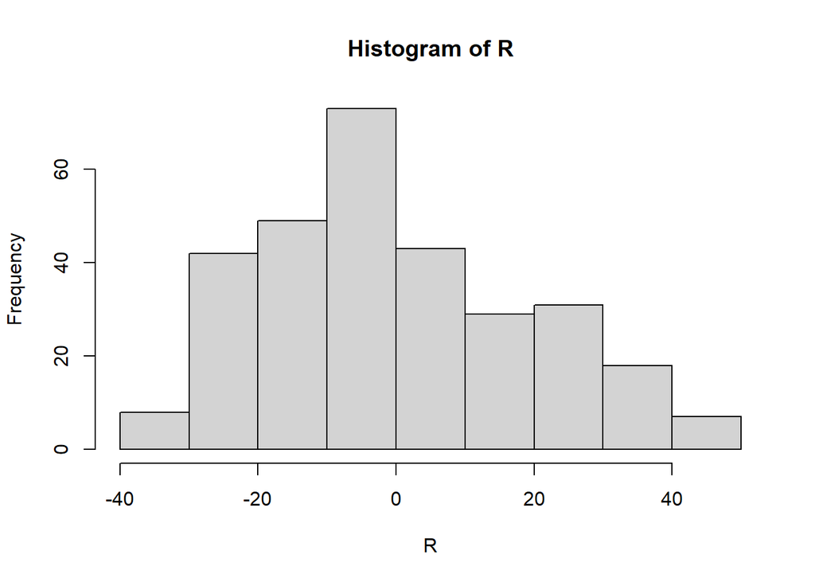

   ```r
   hist(R)
   ```

2. Homogeneity of Variance (Levene’s test), p < 0.05 is non-homogeneous, but if there is little to no group imbalance (*ex* between male/female) this is acceptable.

   ```r
   leveneTest(Pain ~ Sex * Stim * Condition, data = ratings)
   ```

   ```
   ## Levene's Test for Homogeneity of Variance (center = median)
   ##         Df F value    Pr(>F)
   ## group   11  4.4071 1.268e-06 ***
   ##       4988
   ## ---
   ## Signif. codes:  0 '***' 0.001 '**' 0.01 '*' 0.05 '.' 0.1 ' ' 1
   ```

   ```r
   table(ratings$Sex)
   ```

   ```
   ##
   ##   male female
   ##   2504   2496
   ```

   ```r
   table(ratings$Stim)
   ```

   ```
   ##
   ##  low  med high
   ## 1645 1686 1669
   ```

   ```r
   table(ratings$Condition)
   ```

   ```
   ##
   ##    Control Perception
   ##       2460       2540
   ```

3. Sphericity is corrected for with a Greenhouse-Geisser correction when needed.

Plot our results

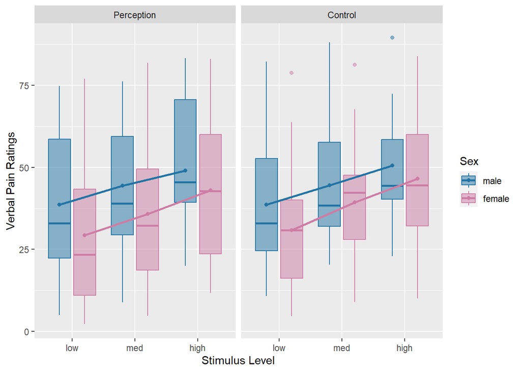

```r
afex_plot(pain.model, x = "Stim", trace = "Sex",
          panel = "Condition", error = "none",
          mapping = c("color", "fill"),
          data_geom = geom_boxplot, data_arg = list(width = 0.7),
          point_arg = list(size = 1.5), line_arg = list(size = 1),
          dodge = 0.8) +
  ylab("Verbal Pain Ratings") +
  xlab("Stimulus Level") +
  scale_fill_manual(values = c("#2274A5", "#CE7DA5")) +
  scale_color_manual(values = c("#2274A5", "#CE7DA5"))
```

$~$

$~$

## Confirmation of Legitimacy: *Did we collect data properly?*

As processing EEG data is a difficult thing, it is important to document your steps thoroughly and facilitate reproduction of your work. The original publication did very well in this endeavor, making their dataset publicly available and detailing their analysis steps, however perfect replication of their processing steps was impossible. Due to use of proprietary software and an (albeit understandable) undescribed process of “visually inspecting ICA components”, the process was reproduced to the best of our ability.

For the time-domain (ERP) analysis, epochs were band-pass filtered from 1-30 Hz. Analyzing each of the three ERP components required processing in the following ways:

1. **N1**: The epochs were re-referenced to *Fz*, and the most negative peak within the time window of 150-180ms was found.
2. **N2**: The epochs remained referenced to *average*, and the most negative peak within the time window of 180-210ms was found.
3. **P2**: The epochs remained referenced to *average*, and the most positive peak within the time window of 290-320ms was found.
4. **Baseline**: The epochs remained referenced to *average*, and the mean absolute power of activity within the time window of -1000-0ms was found.

Amplitude was calculated by extracting the mean amplitude of the data over the given time window for each component (as was done by the original publication).

For the time-frequency (Gamma) analysis, a sliding window of 250ms long with a step size of 20ms was “slid” across the epochs. At each step, an FFT (using DPSS tapers, the MNE default) was calculated for the frequencies between 70-90 Hz at channels *Cz*, *FCz*, and *C2*. From this full-epoch PSD, the -1000-0ms window was extracted as a baseline, while the gamma band amplitude was extracted as the mean of the power from 70-90 Hz between 140-360ms. Note that this is larger than the original paper’s window of 150-350ms, and this change was made such that the time range of focus lined up with the steps of our sliding window (i.e. 140 is a multiple of 20ms, 150 is not).

Note that all of the above was performed for every subject (N=51) in every condition (Perception, EDA, Motor, and Control), however in the Motor condition subject 18’s data was removed by the original authors. Subject 18 is removed from all further analyses for the sake of statistical consistency, balancing the groups to 25 male and 25 female subjects.

### Figures of ERP and Gamma Activity

Note that these figures are averaged across all 4 conditions (Perception, EDA, Motor, and Control), aggregated only by Sex and Stimulus.

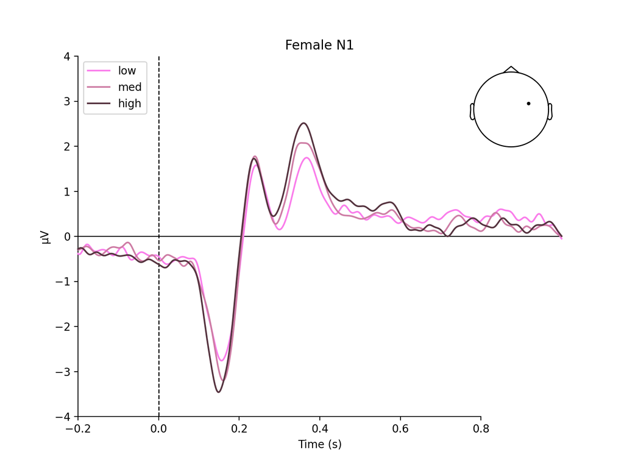

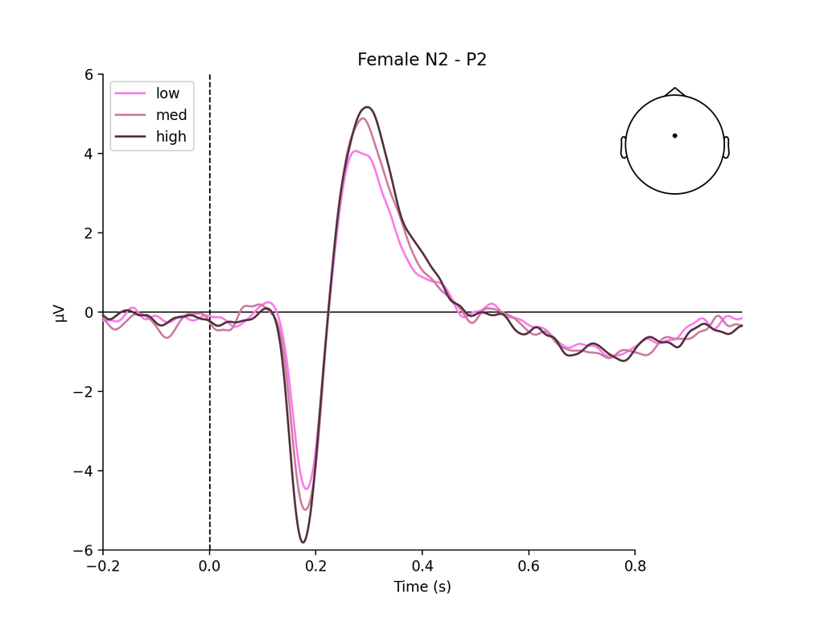

Female ERPs

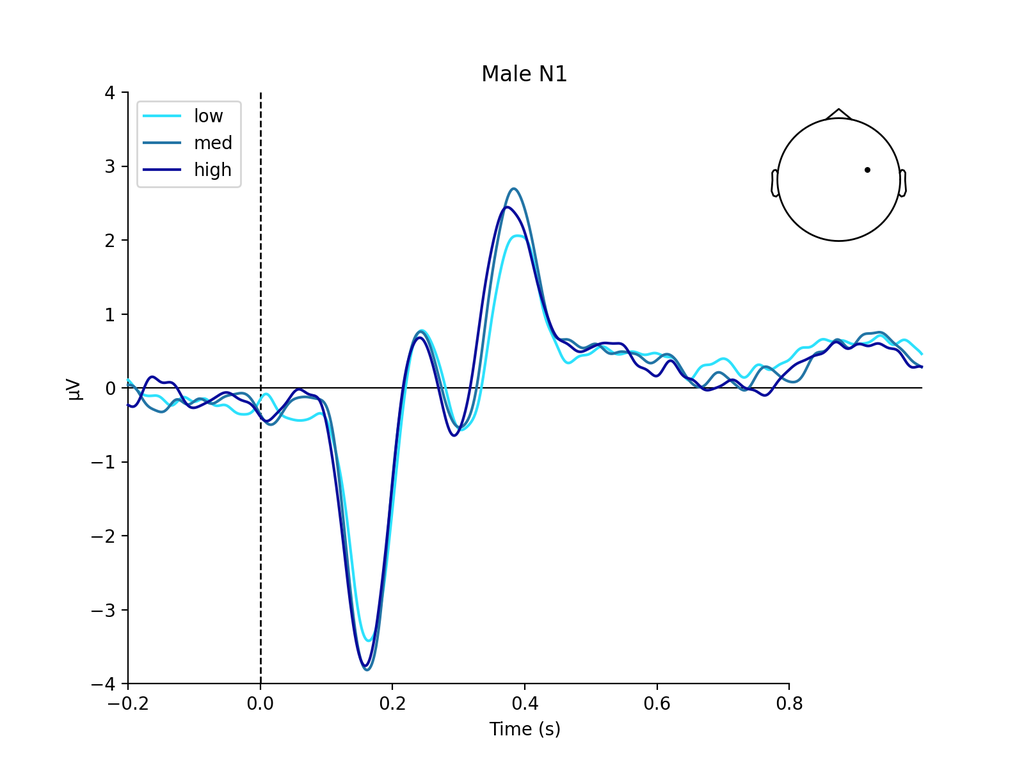

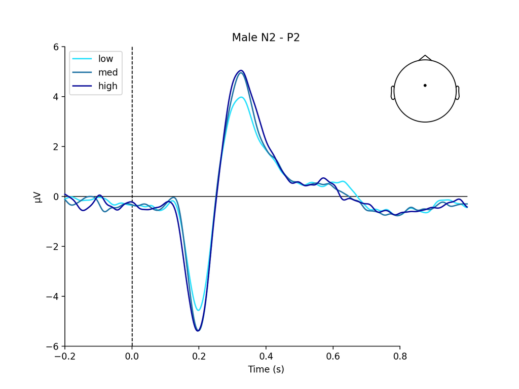

Male ERPs

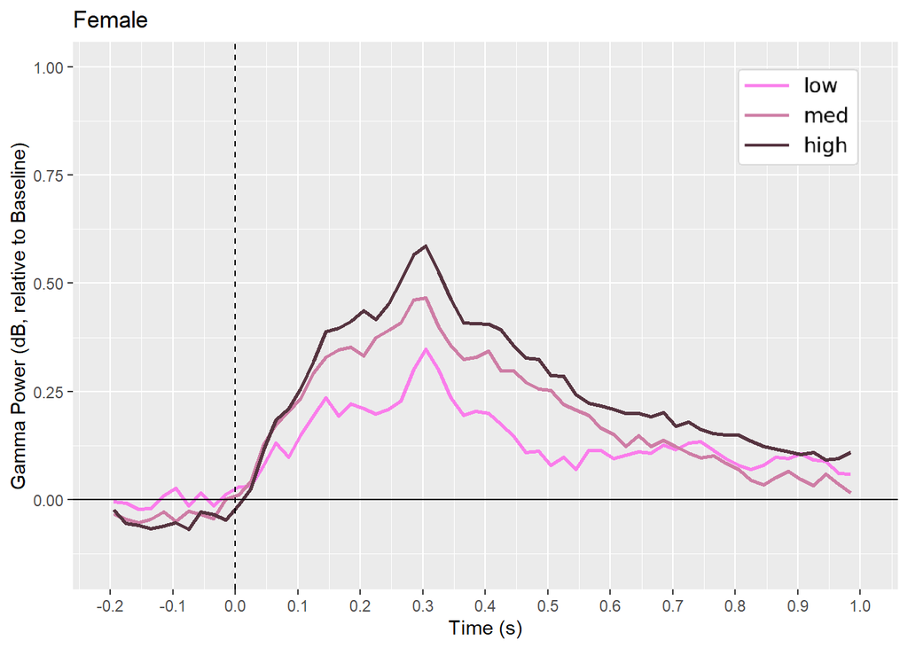

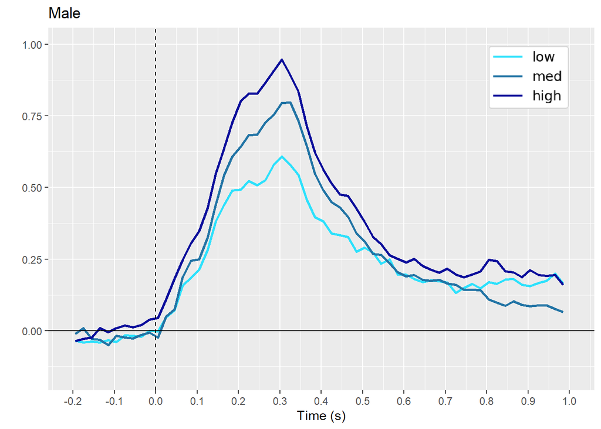

Female vs Male Gamma Power

```r
maleGammaTS_1 <- read_csv("../Figures/maleGammaTS_1.csv",
    col_types = cols(...1 = col_skip()))
maleGammaTS_2 <- read_csv("../Figures/maleGammaTS_2.csv",
    col_types = cols(...1 = col_skip()))
maleGammaTS_3 <- read_csv("../Figures/maleGammaTS_3.csv",
    col_types = cols(...1 = col_skip()))

femaleGammaTS_1 <- read_csv("../Figures/femaleGammaTS_1.csv",
    col_types = cols(...1 = col_skip()))
femaleGammaTS_2 <- read_csv("../Figures/femaleGammaTS_2.csv",
    col_types = cols(...1 = col_skip()))
femaleGammaTS_3 <- read_csv("../Figures/femaleGammaTS_3.csv",
    col_types = cols(...1 = col_skip()))

# since we used a 250 ms time window but marked with the start of it, we correct the time stamps to be the center of the window
maleGammaTS_1$Time <- maleGammaTS_1$Time + 0.125
maleGammaTS_2$Time <- maleGammaTS_2$Time + 0.125
maleGammaTS_3$Time <- maleGammaTS_3$Time + 0.125
femaleGammaTS_1$Time <- femaleGammaTS_1$Time + 0.125
femaleGammaTS_2$Time <- femaleGammaTS_2$Time + 0.125
femaleGammaTS_3$Time <- femaleGammaTS_3$Time + 0.125

Mlegend <- readPNG('../Figures/maleLegend.png')
Flegend <- readPNG('../Figures/femaleLegend.png')

ggplot() +
  geom_line(data = femaleGammaTS_1, aes(x = Time, y = Gamma), color = "#FA7DEB", linewidth = 1) +
  geom_line(data = femaleGammaTS_2, aes(x = Time, y = Gamma), color = "#CE7DA5", linewidth = 1) +
  geom_line(data = femaleGammaTS_3, aes(x = Time, y = Gamma), color = "#563440", linewidth = 1) +
  annotation_raster(Flegend, ymin = 0.77, ymax= 1, xmin = 0.8, xmax = 1) +
  geom_vline(xintercept = 0, linetype="dashed") +
  geom_hline(yintercept = 0, linetype="solid") +
  scale_x_continuous(name = "Time (s)", limits = c(-0.2, 1), breaks = seq(-0.2, 1, 0.1)) +
  ylab("Gamma Power (dB, relative to Baseline)") +
  ylim(-0.15, 1) +
  ggtitle("Female")
ggplot() +
  geom_line(data = maleGammaTS_1, aes(x = Time, y = Gamma), color = "#2DE1FC", linewidth = 1) +
  geom_line(data = maleGammaTS_2, aes(x = Time, y = Gamma), color = "#2274A5", linewidth = 1) +
  geom_line(data = maleGammaTS_3, aes(x = Time, y = Gamma), color = "#090C9B", linewidth = 1) +
  annotation_raster(Mlegend, ymin = 0.77, ymax= 1, xmin = 0.8, xmax = 1) +
  geom_vline(xintercept = 0, linetype="dashed") +
  geom_hline(yintercept = 0, linetype="solid") +
  scale_x_continuous(name = "Time (s)", limits = c(-0.2, 1), breaks = seq(-0.2, 1, 0.1)) +
  ylab("") +  # hide the y label, since it's already next to another chart
  ylim(-0.15, 1) +
  ggtitle("Male")
```

### ERP and Gamma Activity Relative to Baseline

As our processing steps differed slightly from the original publication, a comparison of ERP components and Gamma activity to the baseline period was performed to ensure that the data was collected at least *somewhat* similarly.

First, all four conditions’ data is loaded.

```r
erp1 <- read_csv("Perception_erp.csv", col_types = cols(...1 = col_skip(),
                Sex = col_factor(levels = c("male", "female")),
                Stimulus = col_factor(levels = c("1", "2", "3"))))
erp1$Condition <- "Perception"
erp2 <- read_csv("EDA_erp.csv", col_types = cols(...1 = col_skip(),
                Sex = col_factor(levels = c("male", "female")),
                Stimulus = col_factor(levels = c("1", "2", "3"))))
erp2$Condition <- "EDA"
erp3 <- read_csv("Motor_erp.csv", col_types = cols(...1 = col_skip(),
                Sex = col_factor(levels = c("male", "female")),
                Stimulus = col_factor(levels = c("1", "2", "3"))))
erp3$Condition <- "Motor"
erp4 <- read_csv("Control_erp.csv", col_types = cols(...1 = col_skip(),
                Sex = col_factor(levels = c("male", "female")),
                Stimulus = col_factor(levels = c("1", "2", "3"))))
erp4$Condition <- "Control"
erp <- do.call("rbind", list(erp1, erp2, erp3, erp4))

erp <- erp[!duplicated(erp), ]  # remove duplicate rows
erp <- subset(erp, erp$ID!=18)  # exclude subject 18 (DNF motor)
```

Then, the data is cleaned. Any missing data is removed (NAs here indicate that no negative/positive peak was found in the given time window) and the **amplitudes of all ERP components are represented as an absolute value** (rather than N1/N2 being negative). This was chosen to facilitate understanding the data later.

```r
erp <- na.omit(erp)
erp$Value <- abs(erp$Value)
```

We can then visually inspect the ERP components relative to their baseline

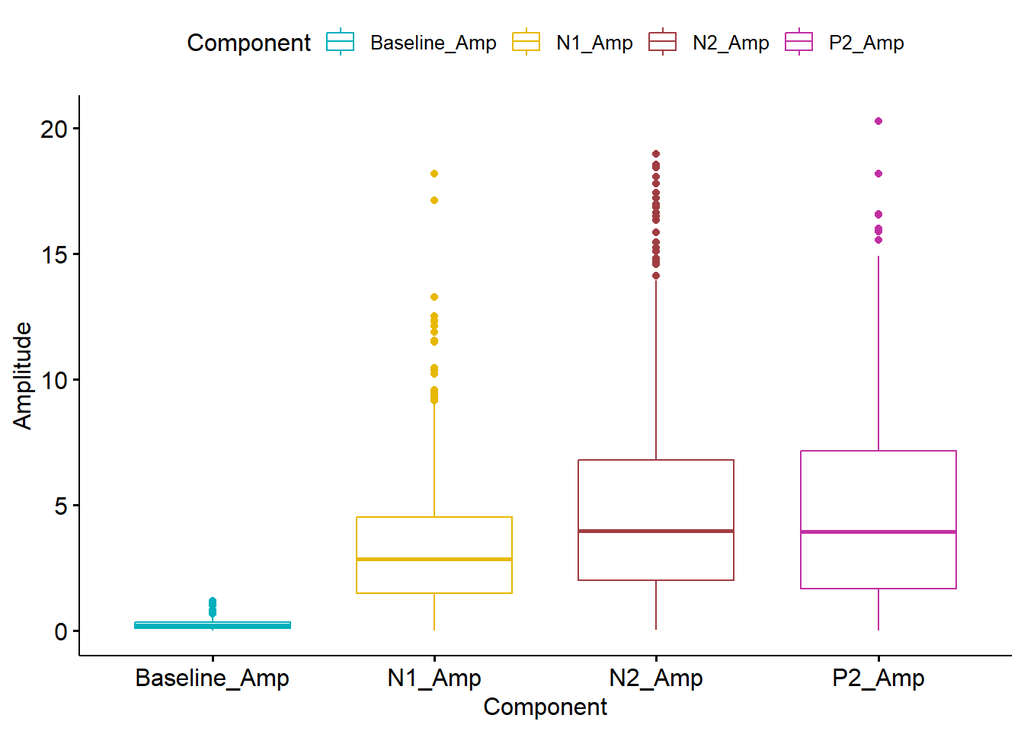

```r
ggboxplot(subset(erp, grepl("Amp", erp$Component, fixed = TRUE)),
          x="Component", y="Value",
          color = "Component", palette = c("#00AFBB", "#E7B800", "#A03D41", "#C130A2"),
          ylab = "Amplitude", xlab = "Component",
          order = c("Baseline_Amp", "N1_Amp", "N2_Amp", "P2_Amp"))
```

To confirm our visual inspection, we also run pairwise t-tests to compare ERP amplitudes to baseline.

```r
difference <- function(df, title, ignore){
  baseline <- subset(df, df$Component=="Baseline_Amp" & !(df$ID %in% ignore))
  test <- subset(df, df$Component==title & !(df$ID %in% ignore))
  # sub-sampling baseline so it equals test in length
  baseline <- baseline[sample(nrow(baseline), length(test$Value)), ]

  data <- rbind(baseline, test)

  # check that the difference is close enough to normal
  d <- baseline$Value - test$Value
  hist(d)

  pairwise_t_test(data, Value ~ Component, paired = TRUE, p.adjust.method = "bonferroni")
}
```

**N1 vs Baseline**

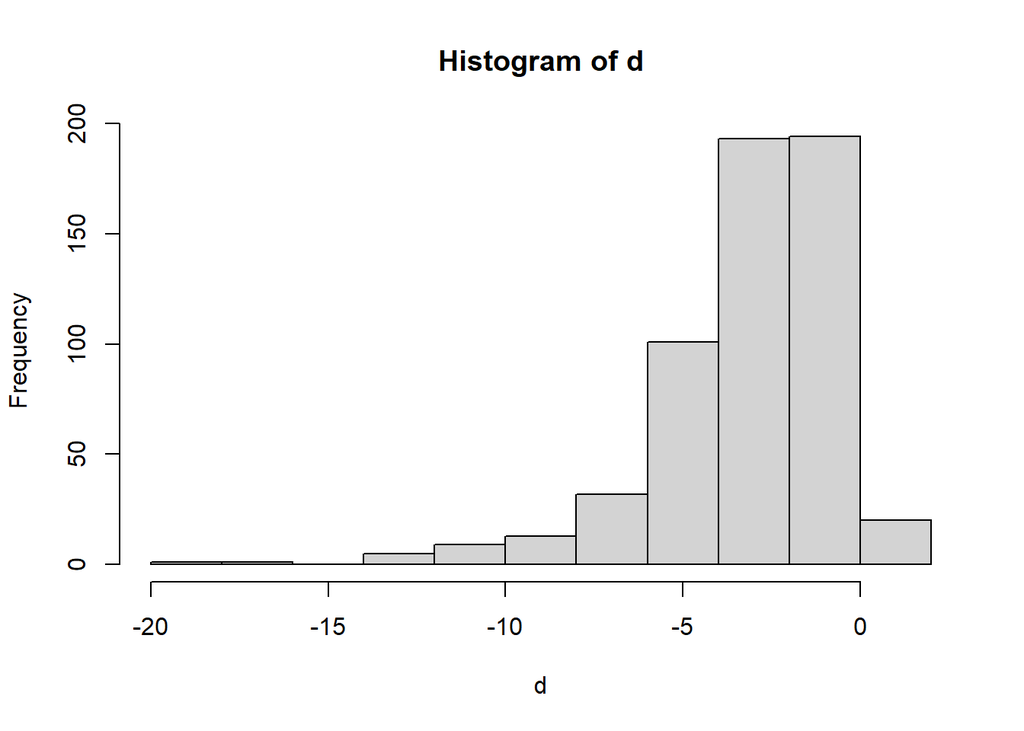

```
## # A tibble: 1 × 10
##   .y.   group1       group2    n1    n2 statistic    df        p    p.adj p.adj.signif
## * <chr> <chr>        <chr>  <int> <int>     <dbl> <dbl>    <dbl>    <dbl> <chr>
## 1 Value Baseline_Amp N1_Amp   569   569     -28.9   568 1.8e-113 1.8e-113 ****
```

```r
difference(erp, "N1_Amp", ignore=c(10, 19))
```

**N2 vs Baseline**

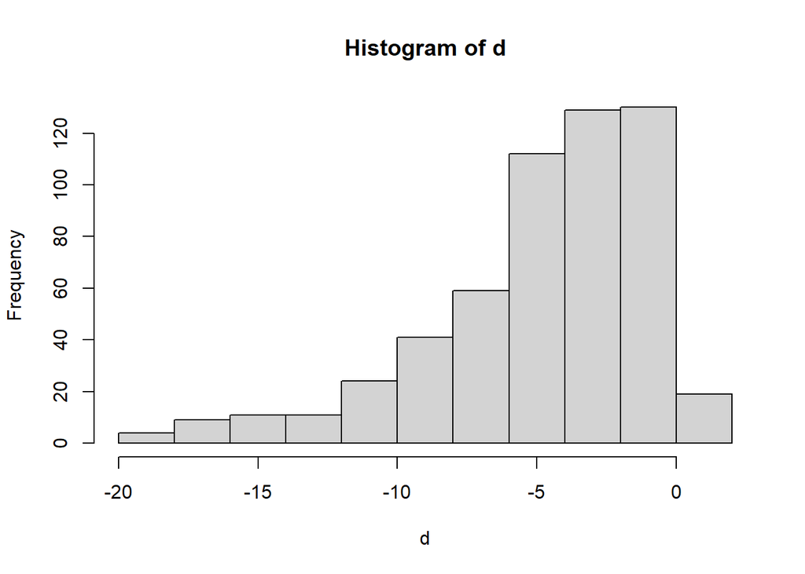

```
## # A tibble: 1 × 10
##   .y.   group1       group2    n1    n2 statistic    df         p     p.adj p.adj.signif
## * <chr> <chr>        <chr>  <int> <int>     <dbl> <dbl>     <dbl>     <dbl> <chr>
## 1 Value Baseline_Amp N2_Amp   549   549     -28.5   548 4.32e-110 4.32e-110 ****
```

```r
difference(erp, "N2_Amp", ignore=c(3, 19, 31, 32))
```

**P2 vs Baseline**

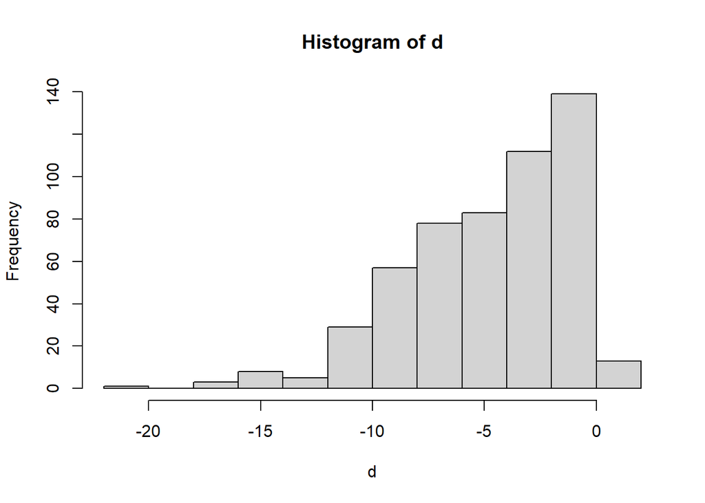

```
## # A tibble: 1 × 10
##   .y.   group1       group2    n1    n2 statistic    df         p     p.adj p.adj.signif
## * <chr> <chr>        <chr>  <int> <int>     <dbl> <dbl>     <dbl>     <dbl> <chr>
## 1 Value Baseline_Amp P2_Amp   528   528     -29.8   527 5.02e-115 5.02e-115 ****
```

```r
difference(erp, "P2_Amp", ignore=c(5, 8, 15, 23, 43))
```

Next, the same steps are take for the gamma band power. Here, it is not necessary to omit NAs, as they are impossible.

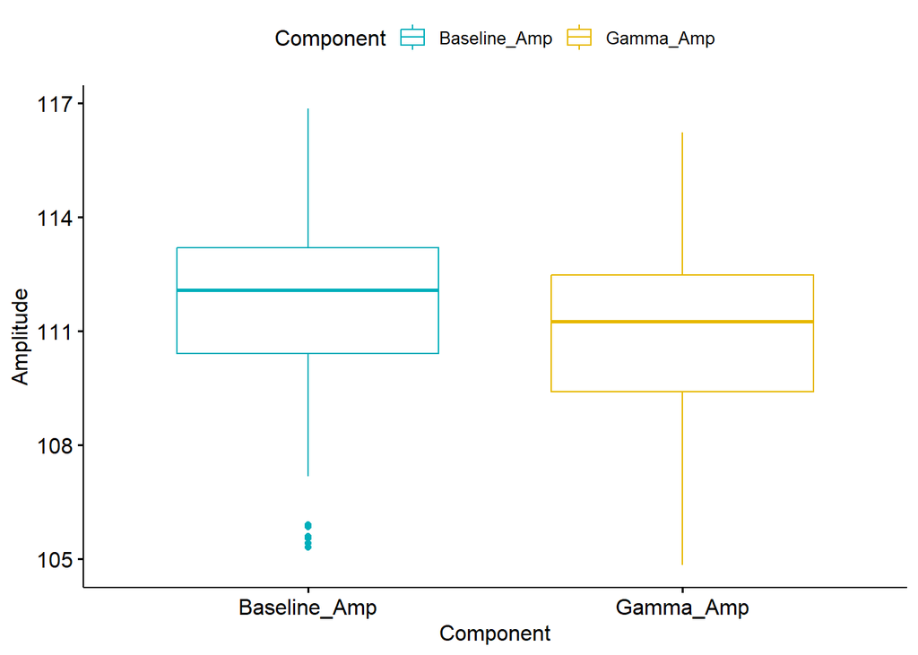

```r
freq1 <- read_csv("Perception_freq.csv", col_types = cols(...1 = col_skip(),
                                              Sex = col_factor(levels = c("male", "female")),
                                              Stimulus = col_factor(levels = c("1", "2", "3"))))
freq1$Condition <- "Perception"
freq2 <- read_csv("EDA_freq.csv", col_types = cols(...1 = col_skip(),
                                              Sex = col_factor(levels = c("male", "female")),
                                              Stimulus = col_factor(levels = c("1", "2", "3"))))
freq2$Condition <- "EDA"
freq3 <- read_csv("Motor_freq.csv", col_types = cols(...1 = col_skip(),
                                              Sex = col_factor(levels = c("male", "female")),
                                              Stimulus = col_factor(levels = c("1", "2", "3"))))
freq3$Condition <- "Motor"
freq4 <- read_csv("Control_freq.csv", col_types = cols(...1 = col_skip(),
                                              Sex = col_factor(levels = c("male", "female")),
                                              Stimulus = col_factor(levels = c("1", "2", "3"))))
freq4$Condition <- "Control"
freq <- do.call("rbind", list(freq1, freq2, freq3, freq4))

freq <- freq[!duplicated(freq), ]  # remove duplicate rows
freq <- subset(freq, freq$ID!=18)  # exclude subject 18 (DNF motor)

freq$Value <- abs(freq$Value)

ggboxplot(subset(freq, grepl("Amp", freq$Component, fixed = TRUE)),
          x="Component", y="Value",
          color = "Component", palette = c("#00AFBB", "#E7B800"),
          ylab = "Amplitude", xlab = "Component",
          order = c("Baseline_Amp", "Gamma_Amp"))
```

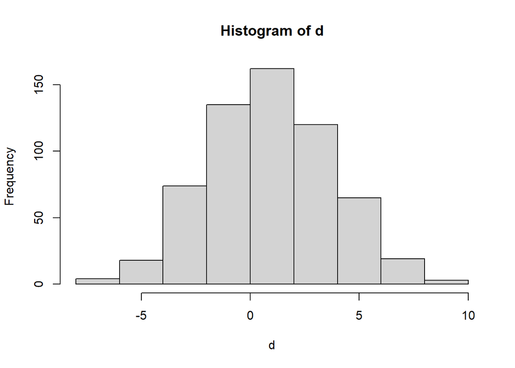

```
## # A tibble: 1 × 10
##   .y.   group1       group2       n1    n2 statistic    df        p    p.adj p.adj.signif
## * <chr> <chr>        <chr>     <int> <int>     <dbl> <dbl>    <dbl>    <dbl> <chr>
## 1 Value Baseline_Amp Gamma_Amp   600   600      7.80   599 2.81e-14 2.81e-14 ****
```

```r
difference(freq, "Gamma_Amp", ignore=c())
```

### Replicating the Findings of the Original Paper

The original paper reported a significant effect of stimulus intensity on all amplitudes (ERP and Gamma) and a significant effect of condition on N1 and Gamma amplitude. We are not interested in this component, but will still check if stimulus intensity significantly modulated amplitudes via the same repeated measures ANOVA.

```r
signif <- function(p) {
  val <- list()
  for (i in seq_len(length(p))){
    if (p[i] < 0.001) {val <- append(val, "***")}
    else if (p[i] < 0.01) {val <- append(val, "**")}
    else if (p[i] < 0.05) {val <- append(val, "*")}
    else if (p[i] < 0.1) {val <- append(val, ".")}
    else if (p[i] >= 0.1) {val <- append(val, " ")}
  }
  return(val)
}

simple_model <- function(df, title) {
  temp <- subset(df, df$Component==title)
  temp <- temp[!duplicated(temp), ]  # remove any duplicated rows

  simple.model <- aov_ez(id = "ID",
                         dv = "Value",
                         data = temp,
                         within = c("Stimulus", "Condition"),
                         fun_aggregate = mean)
  knitr::kable(nice(simple.model))
}
```

**N1 variance explained by Stimulus**

```r
simple_model(erp, "N1_Amp")
```

| Effect | df | MSE | F | ges | p.value |
| --- | --- | --- | --- | --- | --- |
| Stimulus | 1.56, 65.59 | 2.33 | 3.47 * | .004 | .048 |
| Condition | 2.52, 105.74 | 10.22 | 6.41 ** | .047 | .001 |
| Stimulus:Condition | 4.80, 201.62 | 1.07 | 1.76 | .003 | .126 |

$~$

**N2 variance explained by Stimulus**

```r
simple_model(erp, "N2_Amp")
```

| Effect | df | MSE | F | ges | p.value |
| --- | --- | --- | --- | --- | --- |
| Stimulus | 1.48, 63.56 | 3.86 | 6.19 ** | .004 | .007 |
| Condition | 2.87, 123.52 | 22.95 | 2.19 + | .017 | .095 |
| Stimulus:Condition | 5.33, 229.13 | 1.63 | 0.96 | .001 | .449 |

$~$

**P2 variance explained by Stimulus**

```r
simple_model(erp, "P2_Amp")
```

| Effect | df | MSE | F | ges | p.value |
| --- | --- | --- | --- | --- | --- |
| Stimulus | 1.51, 52.88 | 2.89 | 29.33 *** | .022 | <.001 |
| Condition | 2.80, 98.09 | 22.22 | 1.42 | .015 | .242 |
| Stimulus:Condition | 4.66, 163.05 | 2.17 | 1.75 | .003 | .130 |

$~$

**Gamma variance explained by Stimulus**

```r
simple_model(freq, "Gamma_Amp")
```

| Effect | df | MSE | F | ges | p.value |
| --- | --- | --- | --- | --- | --- |
| Stimulus | 1.80, 88.28 | 0.17 | 34.50 *** | .005 | <.001 |
| Condition | 2.81, 137.91 | 4.67 | 11.86 *** | .061 | <.001 |
| Stimulus:Condition | 5.34, 261.79 | 0.12 | 2.35 * | <.001 | .037 |

$~$

$~$

## Comparison Between Sexes

Finally, we take the previously loaded ERP and Gamma data and perform our main analysis. In order to analyze the effect of Sex on physiological markers of pain, we perform a mixed-effects ANOVA with Stimulus Intensity and Condition introduced as within-subject factors and sex as a between-subject factor.

```r
model <- function(df, title, post=FALSE, inter=FALSE) {
  temp <- subset(df, df$Component==title)
  temp <- temp[!(temp$Value %in% boxplot(temp$Value)$out),]  # remove rows with outliers

  full.model <- aov_ez(id = "ID",
                       dv = "Value",
                       data = temp,
                       between = "Sex",
                       within = c("Stimulus", "Condition"),
                       fun_aggregate = mean)

  if (post) {  # if we are running post-hoc...
    post.hoc <- emmeans(full.model, ~ Sex)
    print(summary(as.glht(pairs(post.hoc)), test=adjusted("bonferroni")))
  }
  if (inter) {  # if we have an interaction
    post.hoc <- emmeans(full.model, ~ Sex|Stimulus)
    print(summary(as.glht(pairs(post.hoc)), test=adjusted("bonferroni")))
  }

  # assumption testing
  print("Sample size:")
  print(length(temp$Value))
  print(table(temp$Sex))

  # 1.  Normality
  print("NORMALITY: Visually inspect for non-normal data")
  R = residuals(full.model)
  qqPlot(R)
  hist(R)

  # 2.  Homogeneity of Variance (Levene's test)
  print("HOMOGENEITY OF VARIANCE: For Levene's test, p of < 0.05 is a violation, but if there is little to no group imbalance (ex: between male/female) this is acceptable")
  print(leveneTest(Value ~ Sex * Stimulus * Condition, data = temp))
  print(table(temp$Sex))
  print(table(temp$Stimulus))
  print(table(temp$Condition))

  # 3. Sphericity
  print("Violations of sphericity have been Greenhouse-Geisser corrected")

  return(full.model)
}
```

$~$

### N1 variance explained by Sex

```r
m <- model(erp, "N1_Amp", inter=TRUE)
```

```
## Contrasts set to contr.sum for the following variables: Sex
```

```
## $`Stimulus = X1`
##
##   Simultaneous Tests for General Linear Hypotheses
##
## Linear Hypotheses:
##                    Estimate Std. Error t value Pr(>|t|)
## male - female == 0   0.5126     0.3883    1.32    0.196
## (Adjusted p values reported -- bonferroni method)
##
##
## $`Stimulus = X2`
##
##   Simultaneous Tests for General Linear Hypotheses
##
## Linear Hypotheses:
##                    Estimate Std. Error t value Pr(>|t|)
## male - female == 0   0.5033     0.3996    1.26    0.216
## (Adjusted p values reported -- bonferroni method)
##
##
## $`Stimulus = X3`
##
##   Simultaneous Tests for General Linear Hypotheses
##
## Linear Hypotheses:
##                    Estimate Std. Error t value Pr(>|t|)
## male - female == 0 -0.06267    0.41706   -0.15    0.881
## (Adjusted p values reported -- bonferroni method)
##
##
## [1] "Sample size:"
## [1] 567
##
##   male female
##    279    288
## [1] "NORMALITY: Visually inspect for non-normal data"
```

```
## Data was changed during ANOVA calculation. Thus, residuals cannot be added to original data.
## residuals(..., append = TRUE) will return data and residuals.
```

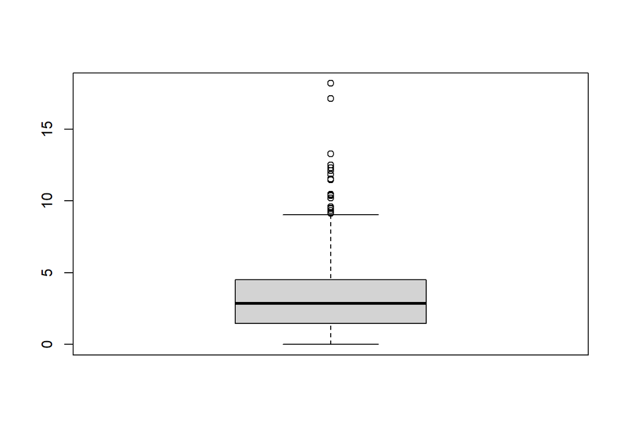

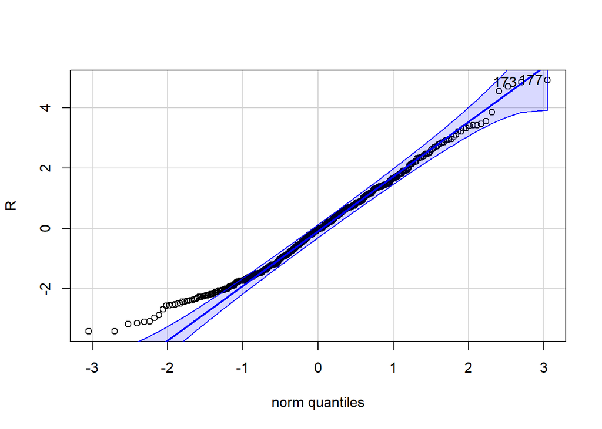

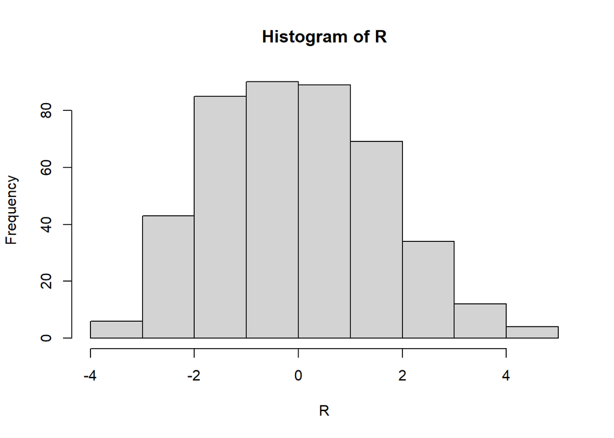

```
## [1] "HOMOGENEITY OF VARIANCE: For Levene's test, p of < 0.05 is a violation, but if there is little to no group imbalance (ex: between male/female) this is acceptable"
## Levene's Test for Homogeneity of Variance (center = median)
##        Df F value Pr(>F)
## group  23  0.6396 0.9019
##       543
##
##   male female
##    279    288
##
##   1   2   3
## 189 190 188
##
##    Control        EDA      Motor Perception
##        149        141        136        141
## [1] "Violations of sphericity have been Greenhouse-Geisser corrected"
```

```r
knitr::kable(nice(m))
```

| Effect | df | MSE | F | ges | p.value |
| --- | --- | --- | --- | --- | --- |
| Sex | 1, 34 | 15.32 | 0.71 | .010 | .406 |
| Stimulus | 1.71, 58.23 | 1.20 | 3.28 + | .006 | .052 |
| Sex:Stimulus | 1.71, 58.23 | 1.20 | 3.78 * | .007 | .035 |
| Condition | 2.89, 98.37 | 3.97 | 6.48 *** | .062 | <.001 |
| Sex:Condition | 2.89, 98.37 | 3.97 | 1.05 | .011 | .374 |
| Stimulus:Condition | 4.94, 168.06 | 0.90 | 2.12 + | .008 | .066 |
| Sex:Stimulus:Condition | 4.94, 168.06 | 0.90 | 0.70 | .003 | .623 |

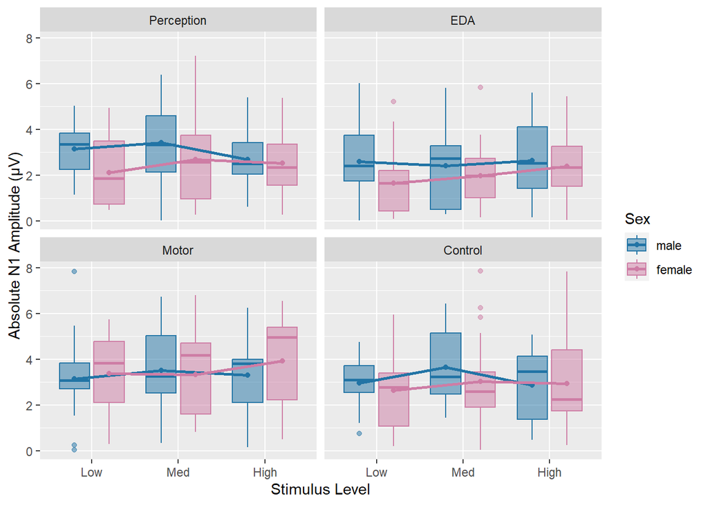

```r
afex_plot(m, x = "Stimulus", trace = "Sex",
          panel = "Condition", error = "none",
          mapping = c("color", "fill"),
          data_geom = geom_boxplot, data_arg = list(width = 0.7),
          point_arg = list(size = 1.5), line_arg = list(size = 1),
          dodge = 0.8) +
  ylab("Absolute N1 Amplitude (μV)") +
  scale_fill_manual(values = c("#2274A5", "#CE7DA5")) +
  scale_color_manual(values = c("#2274A5", "#CE7DA5")) +
  scale_x_discrete(name = "Stimulus Level", labels = c("Low", "Med", "High"))
```

```r
for (i in c("male", "female")) {
  for (j in c("1", "2", "3")){
    for (k in c("Perception", "EDA", "Motor", "Control")){
      m <- mean(subset(erp, erp$Component=="N1_Amp" & erp$Sex==i & erp$Stimulus==j & erp$Condition==k)$Value,
                na.rm = TRUE)
      s <- sd(subset(erp, erp$Component=="N1_Amp" & erp$Sex==i & erp$Stimulus==j & erp$Condition==k)$Value,
              na.rm = TRUE)
      print(sprintf("%s %s %s - %s (%s)", i, j, k, round(m, digits = 1), round(s, digits = 1)))
    }
  }
}
```

```
## [1] "male 1 Perception - 3.7 (2)"
## [1] "male 1 EDA - 2.9 (2.4)"
## [1] "male 1 Motor - 4.2 (3.4)"
## [1] "male 1 Control - 2.9 (1.6)"
## [1] "male 2 Perception - 3.8 (2.5)"
## [1] "male 2 EDA - 3.1 (2.5)"
## [1] "male 2 Motor - 4.7 (3.8)"
## [1] "male 2 Control - 3.6 (2.2)"
## [1] "male 3 Perception - 3.6 (2.6)"
## [1] "male 3 EDA - 3.5 (3.1)"
## [1] "male 3 Motor - 4.6 (3.8)"
## [1] "male 3 Control - 3 (2)"
## [1] "female 1 Perception - 2.4 (2.2)"
## [1] "female 1 EDA - 1.9 (2)"
## [1] "female 1 Motor - 3.8 (2.5)"
## [1] "female 1 Control - 2.8 (1.7)"
## [1] "female 2 Perception - 3 (2.8)"
## [1] "female 2 EDA - 2.5 (1.8)"
## [1] "female 2 Motor - 3.8 (2.7)"
## [1] "female 2 Control - 3.2 (2.2)"
## [1] "female 3 Perception - 2.6 (2.4)"
## [1] "female 3 EDA - 2.7 (1.7)"
## [1] "female 3 Motor - 4.1 (2.4)"
## [1] "female 3 Control - 3.1 (2.1)"
```

$~$

### N2 variance explained by Sex

```r
m <- model(erp, "N2_Amp")
```

```
## Contrasts set to contr.sum for the following variables: Sex
```

```
## [1] "Sample size:"
## [1] 555
##
##   male female
##    286    269
## [1] "NORMALITY: Visually inspect for non-normal data"
```

```
## Data was changed during ANOVA calculation. Thus, residuals cannot be added to original data.
## residuals(..., append = TRUE) will return data and residuals.
```

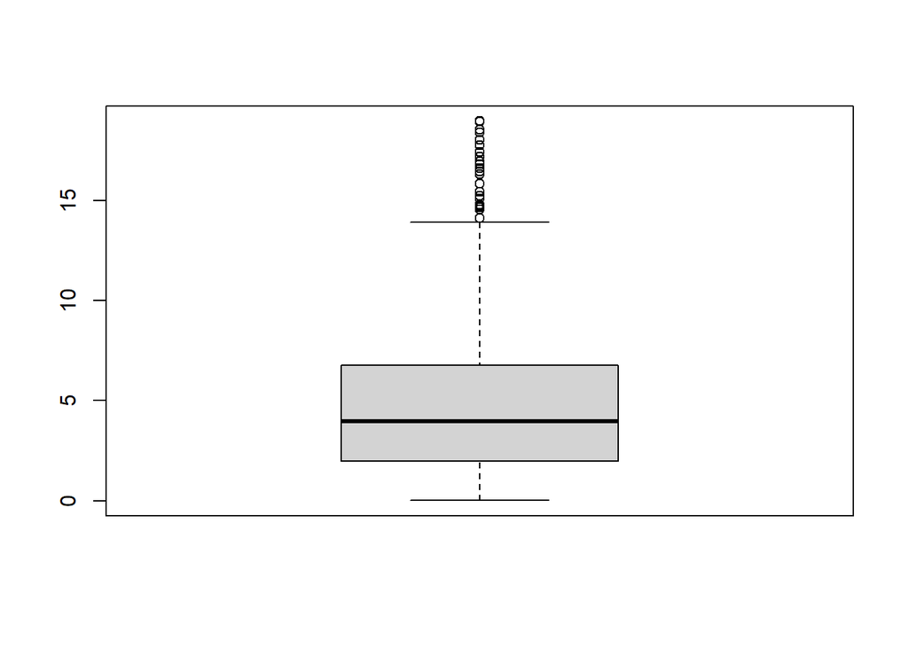

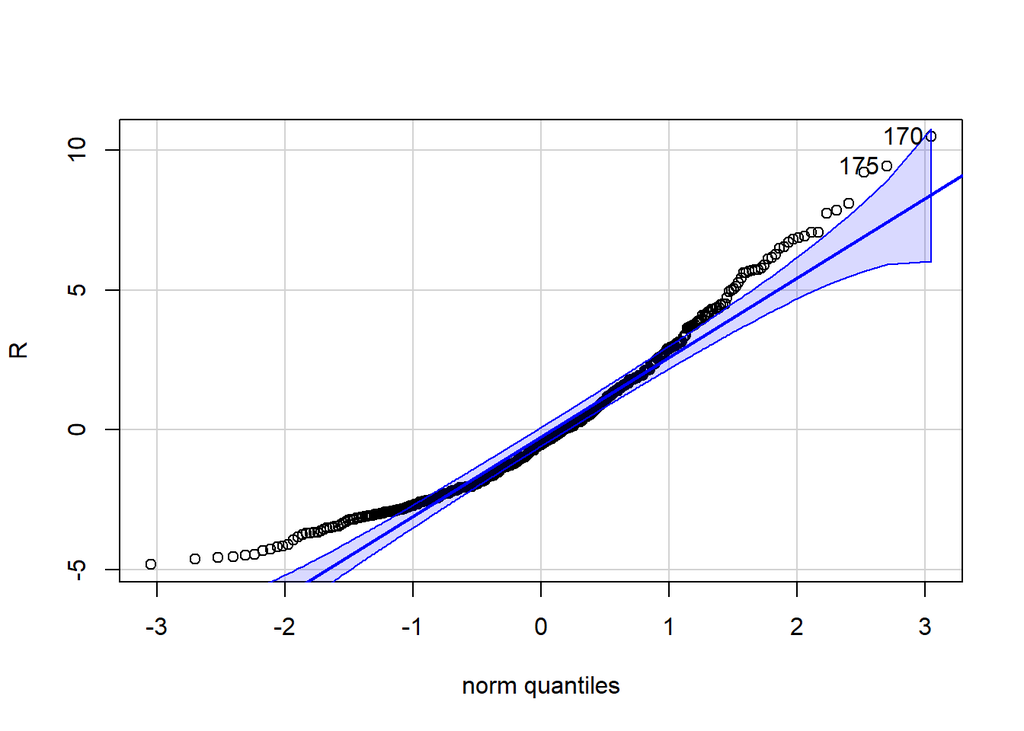

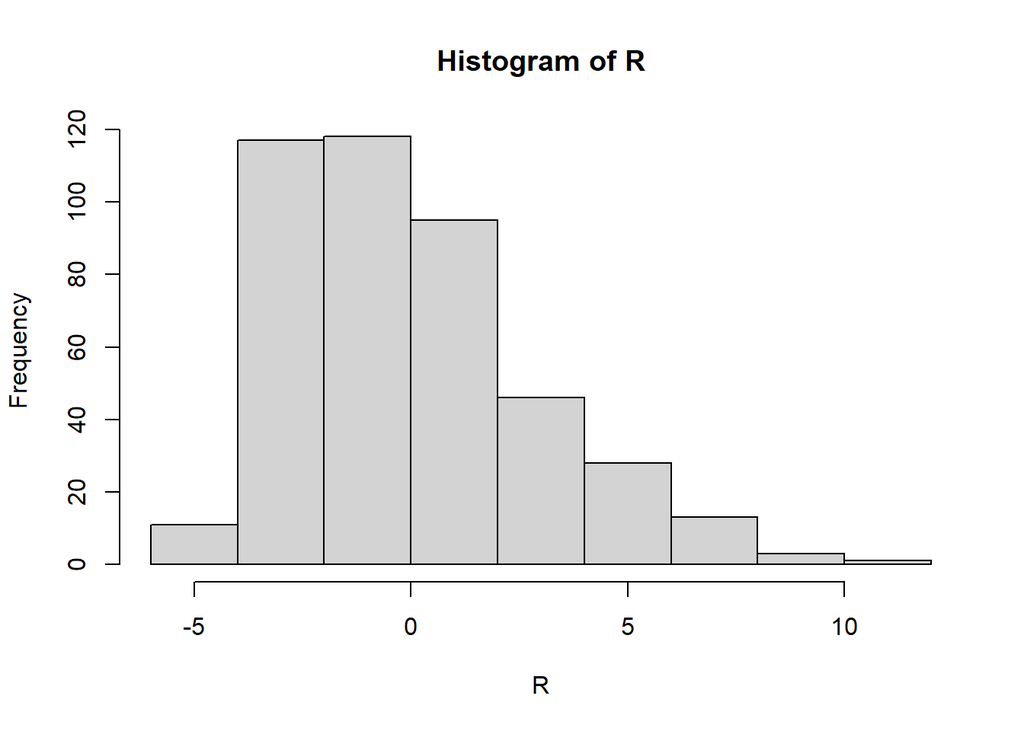

```
## [1] "HOMOGENEITY OF VARIANCE: For Levene's test, p of < 0.05 is a violation, but if there is little to no group imbalance (ex: between male/female) this is acceptable"
## Levene's Test for Homogeneity of Variance (center = median)
##        Df F value Pr(>F)
## group  23  0.7009 0.8469
##       531
##
##   male female
##    286    269
##
##   1   2   3
## 182 186 187
##
##    Control        EDA      Motor Perception
##        142        142        132        139
## [1] "Violations of sphericity have been Greenhouse-Geisser corrected"
```

```r
knitr::kable(nice(m))
```

| Effect | df | MSE | F | ges | p.value |
| --- | --- | --- | --- | --- | --- |
| Sex | 1, 34 | 44.52 | 2.38 | .030 | .132 |
| Stimulus | 1.64, 55.84 | 2.28 | 1.67 | .002 | .201 |
| Sex:Stimulus | 1.64, 55.84 | 2.28 | 0.39 | <.001 | .641 |
| Condition | 2.85, 96.86 | 15.96 | 0.59 | .008 | .614 |
| Sex:Condition | 2.85, 96.86 | 15.96 | 0.67 | .009 | .566 |
| Stimulus:Condition | 5.09, 172.92 | 1.47 | 0.36 | <.001 | .876 |
| Sex:Stimulus:Condition | 5.09, 172.92 | 1.47 | 0.96 | .002 | .446 |

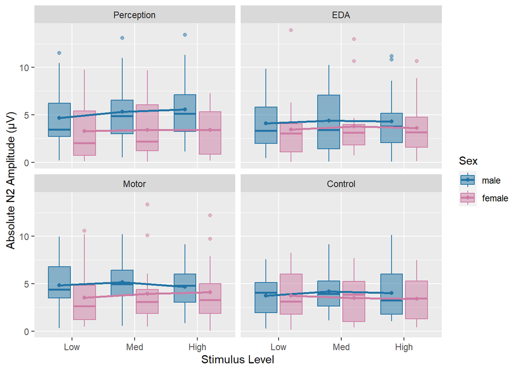

```r
afex_plot(m, x = "Stimulus", trace = "Sex",
          panel = "Condition", error = "none",
          mapping = c("color", "fill"),
          data_geom = geom_boxplot, data_arg = list(width = 0.7),
          point_arg = list(size = 1.5), line_arg = list(size = 1),
          dodge = 0.8) +
  ylab("Absolute N2 Amplitude (μV)") +
  scale_fill_manual(values = c("#2274A5", "#CE7DA5")) +
  scale_color_manual(values = c("#2274A5", "#CE7DA5")) +
  scale_x_discrete(name = "Stimulus Level", labels = c("Low", "Med", "High"))
```

```r
for (i in c("male", "female")) {
  for (j in c("1", "2", "3")){
    for (k in c("Perception", "EDA", "Motor", "Control")){
      m <- mean(subset(erp, erp$Component=="N2_Amp" & erp$Sex==i & erp$Stimulus==j & erp$Condition==k)$Value,
                na.rm = TRUE)
      s <- sd(subset(erp, erp$Component=="N2_Amp" & erp$Sex==i & erp$Stimulus==j & erp$Condition==k)$Value,
              na.rm = TRUE)
      print(sprintf("%s %s %s - %s (%s)", i, j, k, round(m, digits = 1), round(s, digits = 1)))
    }
  }
}
```

```
## [1] "male 1 Perception - 5.6 (3.7)"
## [1] "male 1 EDA - 4 (3.1)"
## [1] "male 1 Motor - 5.4 (3.6)"
## [1] "male 1 Control - 3.7 (2.4)"
## [1] "male 2 Perception - 6.3 (4.2)"
## [1] "male 2 EDA - 4.9 (3.5)"
## [1] "male 2 Motor - 5.9 (3.9)"
## [1] "male 2 Control - 4.5 (2.4)"
## [1] "male 3 Perception - 6.9 (4.7)"
## [1] "male 3 EDA - 4.9 (3.8)"
## [1] "male 3 Motor - 5.6 (3.9)"
## [1] "male 3 Control - 4.4 (2.8)"
## [1] "female 1 Perception - 4 (4)"
## [1] "female 1 EDA - 4.3 (4.5)"
## [1] "female 1 Motor - 4.8 (5.2)"
## [1] "female 1 Control - 4.7 (3.4)"
## [1] "female 2 Perception - 4.3 (4.4)"
## [1] "female 2 EDA - 4.7 (4.2)"
## [1] "female 2 Motor - 4.9 (5)"
## [1] "female 2 Control - 4.5 (3.7)"
## [1] "female 3 Perception - 4.5 (4)"
## [1] "female 3 EDA - 4.8 (4.2)"
## [1] "female 3 Motor - 5.2 (5.2)"
## [1] "female 3 Control - 4.4 (3.1)"
```

$~$

### P2 variance explained by Sex

```r
m <- model(erp, "P2_Amp")
```

```
## Contrasts set to contr.sum for the following variables: Sex
```

```
## [1] "Sample size:"
## [1] 558
##
##   male female
##    279    279
## [1] "NORMALITY: Visually inspect for non-normal data"
```

```
## Data was changed during ANOVA calculation. Thus, residuals cannot be added to original data.
## residuals(..., append = TRUE) will return data and residuals.
```

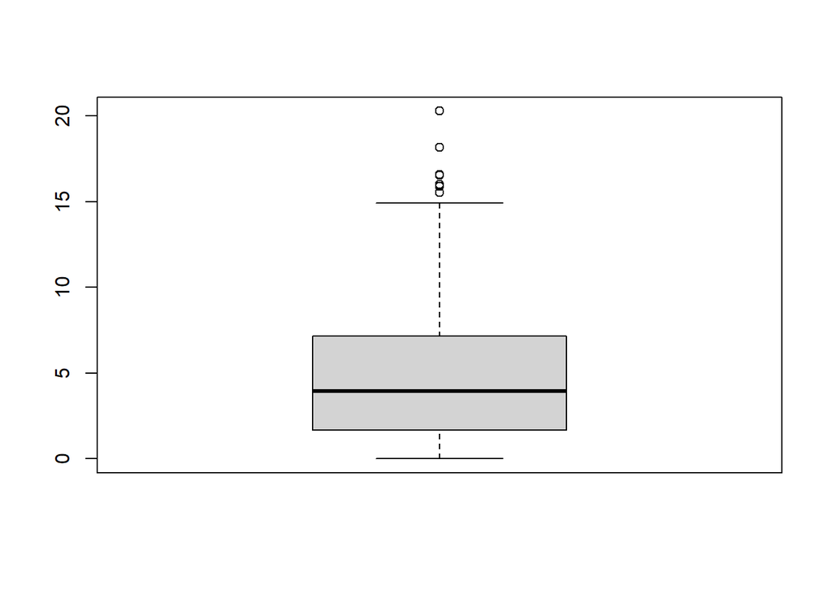

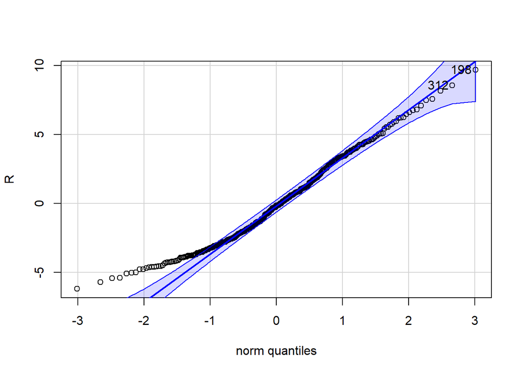

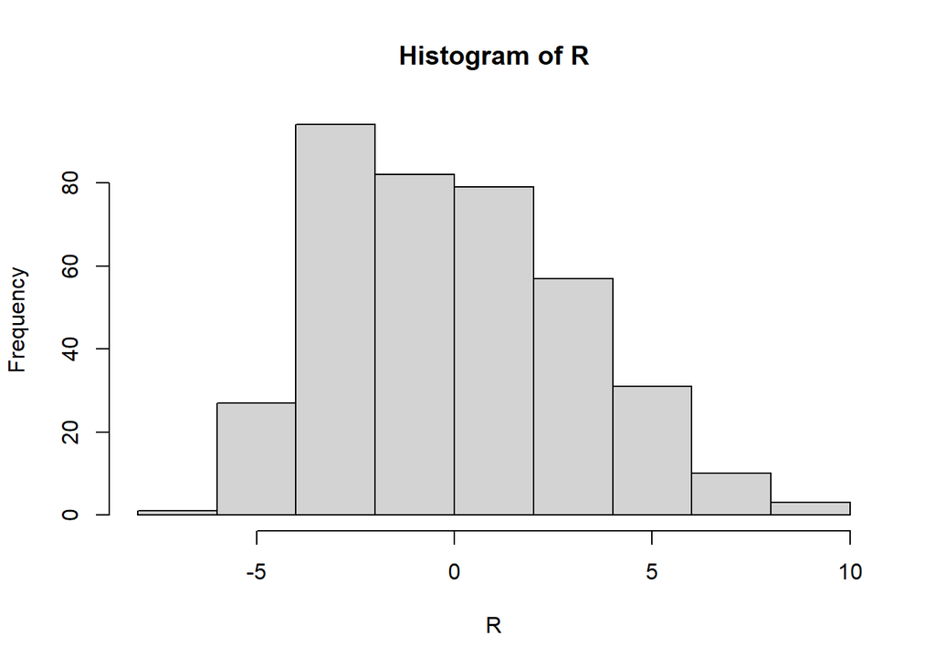

```
## [1] "HOMOGENEITY OF VARIANCE: For Levene's test, p of < 0.05 is a violation, but if there is little to no group imbalance (ex: between male/female) this is acceptable"
## Levene's Test for Homogeneity of Variance (center = median)
##        Df F value Pr(>F)
## group  23  1.0947  0.346
##       534
##
##   male female
##    279    279
##
##   1   2   3
## 186 183 189
##
##    Control        EDA      Motor Perception
##        142        141        130        145
## [1] "Violations of sphericity have been Greenhouse-Geisser corrected"
```

```r
knitr::kable(nice(m))
```

| Effect | df | MSE | F | ges | p.value |
| --- | --- | --- | --- | --- | --- |
| Sex | 1, 30 | 55.42 | 0.04 | <.001 | .848 |
| Stimulus | 1.62, 48.47 | 2.50 | 26.37 *** | .028 | <.001 |
| Sex:Stimulus | 1.62, 48.47 | 2.50 | 0.02 | <.001 | .961 |
| Condition | 2.72, 81.53 | 19.46 | 0.85 | .012 | .460 |
| Sex:Condition | 2.72, 81.53 | 19.46 | 1.29 | .018 | .285 |
| Stimulus:Condition | 4.24, 127.10 | 2.09 | 1.95 | .005 | .102 |
| Sex:Stimulus:Condition | 4.24, 127.10 | 2.09 | 1.01 | .002 | .407 |

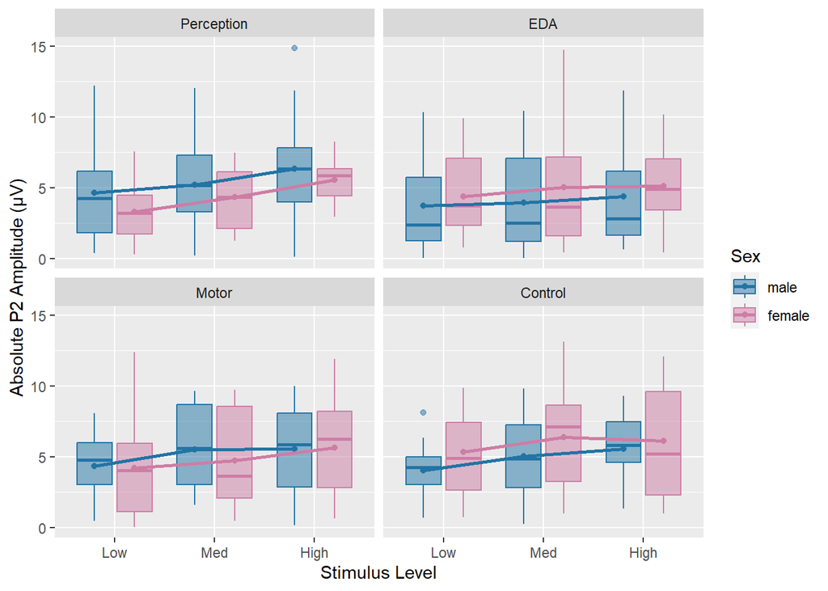

```r
afex_plot(m, x = "Stimulus", trace = "Sex",
          panel = "Condition", error = "none",
          mapping = c("color", "fill"),
          data_geom = geom_boxplot, data_arg = list(width = 0.7),
          point_arg = list(size = 1.5), line_arg = list(size = 1),
          dodge = 0.8) +
  ylab("Absolute P2 Amplitude (μV)") +
  scale_fill_manual(values = c("#2274A5", "#CE7DA5")) +
  scale_color_manual(values = c("#2274A5", "#CE7DA5")) +
  scale_x_discrete(name = "Stimulus Level", labels = c("Low", "Med", "High"))
```

```r
for (i in c("male", "female")) {
  for (j in c("1", "2", "3")){
    for (k in c("Perception", "EDA", "Motor", "Control")){
      m <- mean(subset(erp, erp$Component=="P2_Amp" & erp$Sex==i & erp$Stimulus==j & erp$Condition==k)$Value,
                na.rm = TRUE)
      s <- sd(subset(erp, erp$Component=="P2_Amp" & erp$Sex==i & erp$Stimulus==j & erp$Condition==k)$Value,
              na.rm = TRUE)
      print(sprintf("%s %s %s - %s (%s)", i, j, k, round(m, digits = 1), round(s, digits = 1)))
    }
  }
}
```

```
## [1] "male 1 Perception - 4.8 (3.9)"
## [1] "male 1 EDA - 3.6 (3.4)"
## [1] "male 1 Motor - 4.5 (2.8)"
## [1] "male 1 Control - 4 (3)"
## [1] "male 2 Perception - 5.3 (3.7)"
## [1] "male 2 EDA - 4.1 (3.5)"
## [1] "male 2 Motor - 5.2 (3.7)"
## [1] "male 2 Control - 4.6 (4.2)"
## [1] "male 3 Perception - 5.9 (4.3)"
## [1] "male 3 EDA - 4 (3.6)"
## [1] "male 3 Motor - 5 (3.6)"
## [1] "male 3 Control - 5.2 (3.5)"
## [1] "female 1 Perception - 3.2 (2.3)"
## [1] "female 1 EDA - 3.9 (3.1)"
## [1] "female 1 Motor - 4.8 (5)"
## [1] "female 1 Control - 4.5 (3.3)"
## [1] "female 2 Perception - 4.4 (3)"
## [1] "female 2 EDA - 4.9 (3.8)"
## [1] "female 2 Motor - 5 (4.9)"
## [1] "female 2 Control - 5.5 (3.5)"
## [1] "female 3 Perception - 5.5 (2.9)"
## [1] "female 3 EDA - 4.9 (3.3)"
## [1] "female 3 Motor - 5.6 (5.2)"
## [1] "female 3 Control - 5.3 (4.2)"
```

$~$